# PML-Project: Exercize type Prediction

Subodhan B Gadgil

September 2, 2017

## Introduction

The goal this report is to predict the manner in which the individuals did the exercise. This is the “classe” variable in the training set. You may use any of the other variables to predict with. You should create a report describing how you built your model, how you used cross validation, what you think the expected out of sample error is, and why you made the choices you did. You will also use your prediction model to predict 20 different test cases.

## Getting and Cleaning of data

We will download the data from the location provided and load the training and testing data frames.

```r
#Training Data
download.file("https://d396qusza40orc.cloudfront.net/predmachlearn/pml-training.csv", destfile = "pml-training.csv")

pmlTrngData = read.csv("pml-training.csv")

#Test Data
download.file("https://d396qusza40orc.cloudfront.net/predmachlearn/pml-testing.csv", destfile = "pml-testing.csv")

pmlTestData = read.csv("pml-testing.csv")

str(pmlTrngData, list.len = 20)
```

```
## 'data.frame':    19622 obs. of  160 variables:
##  $ X                       : int  1 2 3 4 5 6 7 8 9 10 ...
##  $ user_name               : Factor w/ 6 levels "adelmo","carlitos",..: 2 2 2 2 2 2 2 2 2 2 ...
##  $ raw_timestamp_part_1    : int  1323084231 1323084231 1323084231 1323084232 1323084232 1323084232 1323084232 1323084232 1323084232 1323084232 ...
##  $ raw_timestamp_part_2    : int  788290 808298 820366 120339 196328 304277 368296 440390 484323 484434 ...
##  $ cvtd_timestamp          : Factor w/ 20 levels "02/12/2011 13:32",..: 9 9 9 9 9 9 9 9 9 9 ...
##  $ new_window              : Factor w/ 2 levels "no","yes": 1 1 1 1 1 1 1 1 1 1 ...
##  $ num_window              : int  11 11 11 12 12 12 12 12 12 12 ...
##  $ roll_belt               : num  1.41 1.41 1.42 1.48 1.48 1.45 1.42 1.42 1.43 1.45 ...
##  $ pitch_belt              : num  8.07 8.07 8.07 8.05 8.07 8.06 8.09 8.13 8.16 8.17 ...
##  $ yaw_belt                : num  -94.4 -94.4 -94.4 -94.4 -94.4 -94.4 -94.4 -94.4 -94.4 -94.4 ...
##  $ total_accel_belt        : int  3 3 3 3 3 3 3 3 3 3 ...
##  $ kurtosis_roll_belt      : Factor w/ 397 levels "","-0.016850",..: 1 1 1 1 1 1 1 1 1 1 ...
##  $ kurtosis_picth_belt     : Factor w/ 317 levels "","-0.021887",..: 1 1 1 1 1 1 1 1 1 1 ...
##  $ kurtosis_yaw_belt       : Factor w/ 2 levels "","#DIV/0!": 1 1 1 1 1 1 1 1 1 1 ...
##  $ skewness_roll_belt      : Factor w/ 395 levels "","-0.003095",..: 1 1 1 1 1 1 1 1 1 1 ...
##  $ skewness_roll_belt.1    : Factor w/ 338 levels "","-0.005928",..: 1 1 1 1 1 1 1 1 1 1 ...
##  $ skewness_yaw_belt       : Factor w/ 2 levels "","#DIV/0!": 1 1 1 1 1 1 1 1 1 1 ...
##  $ max_roll_belt           : num  NA NA NA NA NA NA NA NA NA NA ...
##  $ max_picth_belt          : int  NA NA NA NA NA NA NA NA NA NA ...
##  $ max_yaw_belt            : Factor w/ 68 levels "","-0.1","-0.2",..: 1 1 1 1 1 1 1 1 1 1 ...
##   [list output truncated]
```

We will partition the training data set so that we can use one part to as training data set and the other as the validation data set to validate the model.

```r
# partition the training dataset
set.seed(602223)
trngPart  <- createDataPartition(pmlTrngData$classe, p=0.66, list=FALSE)
trngData <- pmlTrngData[trngPart, ]
valData  <- pmlTrngData[-trngPart, ]

dim(trngData)
```

```
## [1] 12953   160
```

Based on the quick inspection, first 5 columns seem to be meta data columns and can be safely ignored.

```r
trngData <- trngData[, -(1:5)]
valData <- valData[, -(1:5)]
```

There seem to be multiple columns which have mostly NA values. Let us remove those columns which have no significant information.

```r
# remove columns that have 95% NA values
naCols <- sapply(trngData, function(x) mean(is.na(x))) > 0.95
trngData <- trngData[, naCols==FALSE]
valData  <- valData[, naCols==FALSE]
```

Let us also remove the columns that have negligible variance.

```r
# remove columns with negligible Variance
negliVar <- nearZeroVar(trngData)
trngData <- trngData[, -negliVar]
valData  <- valData[, -negliVar]
dim(trngData)
```

```
## [1] 12953    54
```

## Building prediction Models

The reduced training dataset has 53 variables that affect the outcome (the ‘classe’ variable). We should try and reduce these variables if possible. If we use Random Forest algorithm to see the ‘importance’ of these variables, we can make a determination. Let us plot the importance using varImpPlot().

### Variable reduction

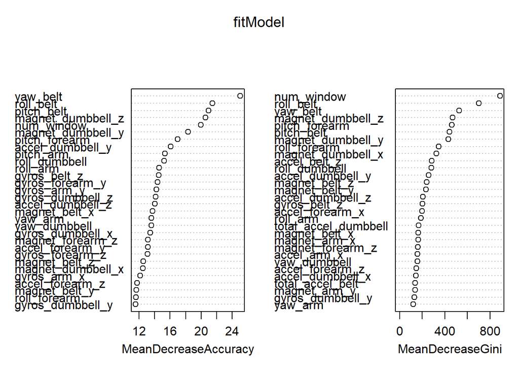

```r
set.seed(31416)
fitModel <- randomForest(classe~., data=trngData, importance=TRUE, ntree=100)

varImpPlot(fitModel)
```

Based on the importance, we can select top 10+ variables and create a subset of the variables for building our prediction model.

```r
imp1<-importance(fitModel)
#get MeanDecreaseAccuracy and MeanDecreaseGini columns
imp1trim <- imp1[,c(6,7)]

#Get two data sets each ordered (in decreasing order) in one of the above two columns
imp1.1<-imp1trim[order(-imp1trim[,1]),]
imp1.2<-imp1trim[order(-imp1trim[,2]),]

# Select top 20 elements from each
imp1.1 <- imp1.1[1:20,]
imp1.2 <- imp1.2[1:20,]

#Get the row names for each
nm1 <- row.names(imp1.1)
nm2 <- row.names(imp1.2)

# and get the column variable names
nm3 <- intersect(nm1, nm2)
print(nm3)
```

```
##  [1] "yaw_belt"          "roll_belt"         "pitch_belt"
##  [4] "magnet_dumbbell_z" "num_window"        "magnet_dumbbell_y"
##  [7] "pitch_forearm"     "accel_dumbbell_y"  "roll_dumbbell"
## [10] "roll_arm"          "gyros_belt_z"      "accel_dumbbell_z"
## [13] "magnet_belt_x"
```

```r
# reduce the raining dataset columns
trngData1 <- trngData[,c("classe", nm3)]
#dim(trngData1)
```

### Model Selection

Now, we will use the following three models for evaluation of prediction suitability:

- RPart
- GBM
- Random Forest

```r
set.seed(124681)
controlRpart <- trainControl(method="cv", number=3, verboseIter = FALSE)

model_rpart <- train(classe~., data = trngData1, trControl = controlRpart, method='rpart')


controlGBM <- trainControl(method = "repeatedcv", number = 5, repeats = 2, verboseIter =  FALSE)

model_gbm <- train(classe~., data = trngData1, trControl = controlGBM, method = 'gbm', verbose=F)
controlRF <- trainControl(method="cv", number=3, verboseIter = FALSE)

model_rf <- train(classe~., data = trngData1, trControl = controlRF, method = 'rf', ntree = 100)
```

Now, let us create predictions using the above models and compare the results using the validation dataset (valData) that we have created.

```r
# predict using Rpart
predictionRpart <- predict(model_rpart, newdata=valData)
cmRpart <- confusionMatrix(predictionRpart, valData$classe)

# predict using gbm
predictionGBM <- predict(model_gbm, newdata=valData)
cmGBM <- confusionMatrix(predictionGBM, valData$classe)

# predict using Random Forest
predictionRF <- predict(model_rf, newdata=valData)
cmRF <- confusionMatrix(predictionRF, valData$classe)


print(cmRpart)
```

```
## Confusion Matrix and Statistics
##
##           Reference
## Prediction    A    B    C    D    E
##          A 1655  312  173  159   41
##          B   41  459   43  230  106
##          C  196  519  947  644  328
##          D    0    0    0    0    0
##          E    5    0    0   60  751
##
## Overall Statistics
##
##                Accuracy : 0.5716
##                  95% CI : (0.5596, 0.5835)
##     No Information Rate : 0.2845
##     P-Value [Acc > NIR] : < 2.2e-16
##
##                   Kappa : 0.4531
##  Mcnemar's Test P-Value : < 2.2e-16
##
## Statistics by Class:
##
##                      Class: A Class: B Class: C Class: D Class: E
## Sensitivity            0.8724  0.35581   0.8143   0.0000   0.6126
## Specificity            0.8565  0.92192   0.6936   1.0000   0.9881
## Pos Pred Value         0.7073  0.52218   0.3595      NaN   0.9203
## Neg Pred Value         0.9441  0.85648   0.9465   0.8361   0.9188
## Prevalence             0.2845  0.19343   0.1744   0.1639   0.1838
## Detection Rate         0.2482  0.06883   0.1420   0.0000   0.1126
## Detection Prevalence   0.3509  0.13180   0.3950   0.0000   0.1224
## Balanced Accuracy      0.8644  0.63887   0.7539   0.5000   0.8003
```

```r
print(cmGBM)
```

```
## Confusion Matrix and Statistics
##
##           Reference
## Prediction    A    B    C    D    E
##          A 1897    2    0    0    2
##          B    0 1279    1    5    4
##          C    0    5 1158    9    5
##          D    0    2    2 1077    5
##          E    0    2    2    2 1210
##
## Overall Statistics
##
##                Accuracy : 0.9928
##                  95% CI : (0.9905, 0.9947)
##     No Information Rate : 0.2845
##     P-Value [Acc > NIR] : < 2.2e-16
##
##                   Kappa : 0.9909
##  Mcnemar's Test P-Value : NA
##
## Statistics by Class:
##
##                      Class: A Class: B Class: C Class: D Class: E
## Sensitivity            1.0000   0.9915   0.9957   0.9854   0.9869
## Specificity            0.9992   0.9981   0.9965   0.9984   0.9989
## Pos Pred Value         0.9979   0.9922   0.9839   0.9917   0.9951
## Neg Pred Value         1.0000   0.9980   0.9991   0.9971   0.9971
## Prevalence             0.2845   0.1934   0.1744   0.1639   0.1838
## Detection Rate         0.2845   0.1918   0.1736   0.1615   0.1814
## Detection Prevalence   0.2851   0.1933   0.1765   0.1628   0.1823
## Balanced Accuracy      0.9996   0.9948   0.9961   0.9919   0.9929
```

```r
print(cmRF)
```

```
## Confusion Matrix and Statistics
##
##           Reference
## Prediction    A    B    C    D    E
##          A 1897    0    0    0    0
##          B    0 1288    4    0    0
##          C    0    2 1159    3    1
##          D    0    0    0 1090    3
##          E    0    0    0    0 1222
##
## Overall Statistics
##
##                Accuracy : 0.9981
##                  95% CI : (0.9967, 0.999)
##     No Information Rate : 0.2845
##     P-Value [Acc > NIR] : < 2.2e-16
##
##                   Kappa : 0.9975
##  Mcnemar's Test P-Value : NA
##
## Statistics by Class:
##
##                      Class: A Class: B Class: C Class: D Class: E
## Sensitivity            1.0000   0.9984   0.9966   0.9973   0.9967
## Specificity            1.0000   0.9993   0.9989   0.9995   1.0000
## Pos Pred Value         1.0000   0.9969   0.9948   0.9973   1.0000
## Neg Pred Value         1.0000   0.9996   0.9993   0.9995   0.9993
## Prevalence             0.2845   0.1934   0.1744   0.1639   0.1838
## Detection Rate         0.2845   0.1931   0.1738   0.1634   0.1832
## Detection Prevalence   0.2845   0.1937   0.1747   0.1639   0.1832
## Balanced Accuracy      1.0000   0.9989   0.9977   0.9984   0.9984
```

based on the analysis of the above three models, it is clear that RPart model does not perform very well in this case. Both Gradient Boosting (GBM) and Random Forest (RF) perform very well, but Random Forest model has a small edge.

### Out-of-Sample error

The Random Forest algorithm provides an accuracy of 99.81% on the validataion dataset that we have created (as per the ConfusionMatrix above).The out-of-sample error rate for the selected Random Forest algorithm is 0.19% (1.00 - Accuracy = .0019, which is 0.19%).

### Final Model

based on the analysis above, we will use Random Forest model to perform the predictions.

## Prediction

Let us perform the prediction of the data provided by ‘pml-testing.csv’.

```r
predictionFinal <- predict(model_rf, newdata = pmlTestData)


AnswerDF <- data.frame(ProblemId = pmlTestData$problem_id, Predicted = predictionFinal)

print(AnswerDF)
```

```
##    ProblemId Predicted
## 1          1         B
## 2          2         A
## 3          3         B
## 4          4         A
## 5          5         A
## 6          6         E
## 7          7         D
## 8          8         B
## 9          9         A
## 10        10         A
## 11        11         B
## 12        12         C
## 13        13         B
## 14        14         A
## 15        15         E
## 16        16         E
## 17        17         A
## 18        18         B
## 19        19         B
## 20        20         B
```